# SIRATES_2022

Inital data visualizations

Sarah Salois

## Pulling in shape files and bathymetry for maps

```r
# Bringing in shape files and bathymetry for maps

wd = ("C:/Users/sarah.salois/Documents/github/ssalois1/calc_wcr_metrics")
US.areas <- rgdal::readOGR(wd, 'USA')
proj4string(US.areas) <- CRS("+init=epsg:4326")
## bring in bathymetry
atl <- marmap::getNOAA.bathy(-73,-69, 39, 42)
atl = fortify.bathy(atl)
blues = colorRampPalette(brewer.pal(9,'Blues'))(25)
depths <- c(0,50,100,200,300,500,Inf)
blues2 <- blues[c(5,7,9,11,13,24)]
coast = map_data("world2Hires")
coast = subset(coast, region %in% c('USA'))
coast$lon = (360 - coast$long)*-1

#plot(US.areas)
```

## Data Wrangling

Manually wrangled lengths and net metrics to be in the long format. Note: I will need to go back and write code to wrangle the excel data from R for efficiency and reproducibility. After loading the pre-wrangled data, I convert bottom temperatures from F to C and depth in fathoms to meters. A quick QC-check on names of unique species.

```r
# Still need to figure out pulling in a workbook
#df <- read_excel('Illex_biological_data fm_2022_Salt_Water_Intrusion.xlsx')
lengths <- read.csv('sirates_lengths.csv')
net_metrics <- read.csv('sirates_net_metrics.csv')
wtml <- read.csv('sirates_length_weights_illex.csv')
unique(lengths$species)
```

```
##  [1] "loligo"              "butterfish"          "illex"
##  [4] "rough_scad"          "whiting"             "spiny_dogfish"
##  [7] "spotted_hake"        "unknown"             "monkfish"
## [10] "moonfish"            "fourspot_flounder"   "gulfstream_flounder"
## [13] "golden_tilefish"     "tilefish"
```

```r
# error in station G, guessing bt was actually 50, may want to make NA
net_metrics[26,10] <- 50.0
# convert to metrics and celcius
net_metrics$bottom_temp_c <- (net_metrics$bottom_temp - 32) * 0.5556
net_metrics$headrope_depth_m <- (net_metrics$headrope_depth * 1.8288)
net_metrics$footrope_depth_m <- (net_metrics$footrope_depth * 1.8288)
# Subset based on two net positions
net_set <- net_metrics %>% filter(net_position == 'net_set')
haul_back <- net_metrics %>% filter(net_position == 'haul_back')
```

## Map of Stations

The following charts out a map of the location of each of the 8 tows.

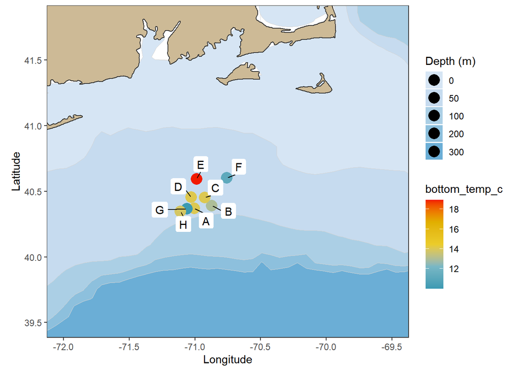

```r
# Set up the dataframe as sf object
#net_set_sp = coordinates(net_set) <- c('lon', 'lat')
#net_set_sp = proj4string(net_set) <- CRS("+init=epsg:4326")
net_set_sf <- st_as_sf(net_set, coords = c(4,3))
# Create a color palette
wespal <- wes_palette("Zissou1")

p = ggplot() +
  geom_contour_filled(data = atl,
                      aes(x=x,y=y,z=-1*z),
                      breaks=c(0,50,100,250,500,Inf),
                      size=c(0.3)) +
  scale_fill_manual(values = blues2, # 5:20
                    name = paste("Depth (m)"),
                    labels = depths) +
  geom_contour(data = atl,
               aes(x=x,y=y,z=-1*z),
               breaks=c(0,50,100,250,500,Inf),
               size=c(0.3),
               col = 'lightgrey') +
  new_scale_fill() +
  geom_sf(data = net_set_sf,
                aes(color = bottom_temp_c), size = 5,
                show.legend = 'point') +
  scale_color_gradientn(colours = wespal) +
  ggrepel::geom_label_repel(data = net_set_sf,
    aes(label = station, geometry = geometry),
    stat = "sf_coordinates",
    min.segment.length = 0,
    label.size = NA,
    #color = text_color
  ) +
  geom_polygon(data = coast, aes(x=lon, y = lat, group = group),
                             color = 'gray20', fill = "wheat3") +
  coord_sf(xlim = c(-72,-69.5), ylim = c(39.5,41.8),
           datum = sf::st_crs(4326)) +
  xlab('Longitude') +
  ylab('Latitude')+
 # guides(fill = 'none') + #color = FALSE, this was attempt to get rid of dots
  theme_bw()
# Plot map with labels
p + geom_text()
```

This is a zoomed in version. *Note: Something changes when I add the second layer of color - depth legend adds points, have tried to fix by specifiying color = z but did not work* + Is potentially addressed [here](https://github.com/tidyverse/ggplot2/issues/2322) may look into for future plotting

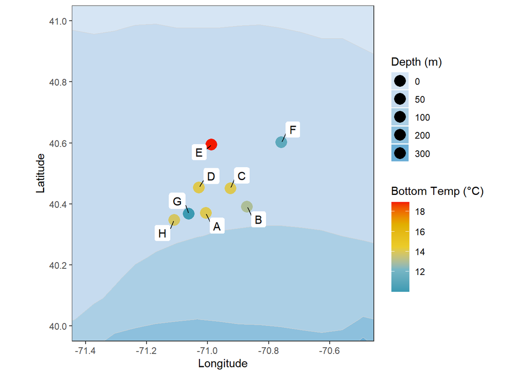

```r
p2 = ggplot() +
  geom_contour_filled(data = atl,
                      aes(x=x,y=y,z=-1*z, color = 1*z),
                      breaks=c(0,50,100,250,500,Inf),
                      size=c(0.3)) +
  scale_fill_manual(values = blues2, # 5:20
                    name = paste("Depth (m)"),
                    labels = depths) +
  geom_contour(data = atl,
               aes(x=x,y=y,z=-1*z),
               breaks=c(0,50,100,250,500,Inf),
               size=c(0.3),
               col = 'lightgrey') +
  new_scale_fill() +
  geom_sf(data = net_set_sf,
          aes(color = bottom_temp_c), size = 5,
          show.legend = 'point') +
  scale_color_gradientn(colours = wespal,
                        name = paste("Bottom Temp (°C)")) +
  ggrepel::geom_label_repel(data = net_set_sf,
                            aes(label = station, geometry = geometry),
                            stat = "sf_coordinates",
                            min.segment.length = 0,
                            label.size = NA) +
  geom_polygon(data = coast, aes(x=lon, y = lat, group = group),
               color = 'gray20', fill = "wheat3") +
  coord_sf(xlim = c(-71.4,-70.5), ylim = c(40.0,41.0),
           datum = sf::st_crs(4326)) +
  xlab('Longitude') +
  ylab('Latitude')+
  guides(fill = 'none') + #color = FALSE,
  theme_bw()

p2 + geom_text()
```

## Interactive maps with Leaflet

Net position : Net set

```r
## -- Leaflet maps -- ##

netset_xyz <- net_set %>%
  st_as_sf(coords = c('lon', 'lat'), crs = 4326)
pal <- colorNumeric(palette = "magma", netset_xyz$bottom_temp_c)

# Net set map
netset_xyz %>%
  st_transform(4326) %>%
  as("Spatial") %>%
  leaflet() %>%
  #addTiles() %>%
  addProviderTiles("Esri.WorldStreetMap") %>%
  addCircles(color = ~pal(bottom_temp_c),
             popup = paste0(
               "<strong>Station: </strong>",
               netset_xyz$station, "<br>",
               "<strong>Net Position: </strong>",
               netset_xyz$net_position, "<br>",
               "<strong>Headrope Depth (m): </strong>",
               netset_xyz$headrope_depth_m, "<br>",
               "<strong>Footrope Depth (m): </strong>",
               netset_xyz$footrope_depth_m, "<br>",
               "<strong>Temperature (°C): </strong>",
               netset_xyz$bottom_temp_c, "<br>"
             )) %>%
  addLegend(pal = pal, values = ~bottom_temp_c,
            title = "Bottom temperature (°C)", opacity = 1)
```

[interactive chart not shown]

Net position : Haul back

```r
# Haul back map
haulback_xyz <- haul_back %>%
  st_as_sf(coords = c('lon', 'lat'), crs = 4326)
pal <- colorNumeric(palette = "magma", haulback_xyz$bottom_temp_c)

haulback_xyz %>%
  st_transform(4326) %>%
  as("Spatial") %>%
  leaflet() %>%
  #addTiles() %>%
  addProviderTiles("Esri.WorldStreetMap") %>%
  addCircles(color = ~pal(bottom_temp_c),
             popup = paste0(
               "<strong>Station: </strong>",
               haulback_xyz$station, "<br>",
               "<strong>Net Position: </strong>",
               haulback_xyz$net_position, "<br>",
               "<strong>Headrope Depth (m): </strong>",
               haulback_xyz$headrope_depth_m, "<br>",
               "<strong>Footrope Depth (m): </strong>",
               haulback_xyz$footrope_depth_m, "<br>",
               "<strong>Temperature (°C): </strong>",
               haulback_xyz$bottom_temp_c, "<br>"
             )) %>%
  addLegend(pal = pal, values = ~bottom_temp_c,
            title = "Bottom temperature (°C)", opacity = 1)
```

[interactive chart not shown]

## Boxplots

### All species:

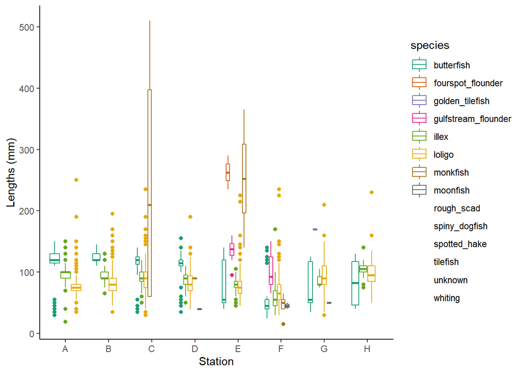

```r
## -- Boxplots -- ##
# All species
p = ggplot(lengths, aes(x = factor(station), y = length, col = species))+
  labs(x = 'Station', y = 'Lengths (mm)')+
  scale_color_brewer(palette = "Dark2") +
  theme_classic() +
  #facet_wrap(~factor(fleet))
  geom_boxplot()
p
```

### Illex vs Loligo

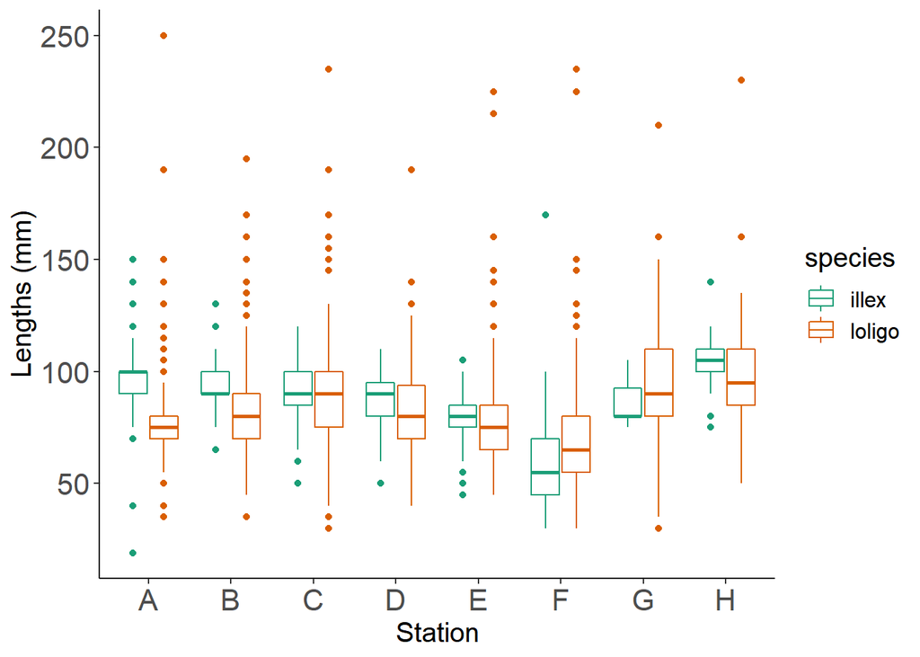

```r
# Illex vs Loligo
p = ggplot(lengths %>% filter(species %in% c('loligo', 'illex')),
           aes(x = factor(station), y = length, col = species))+
  labs(x = 'Station', y = 'Lengths (mm)') +
  scale_color_brewer(palette = "Dark2") +
  theme_classic() +
  #facet_wrap(~factor(fleet))
  geom_boxplot()


p = p +  theme(text = element_text(size = 15),
               axis.text=element_text(size = 16))
p
```

### Just Illex

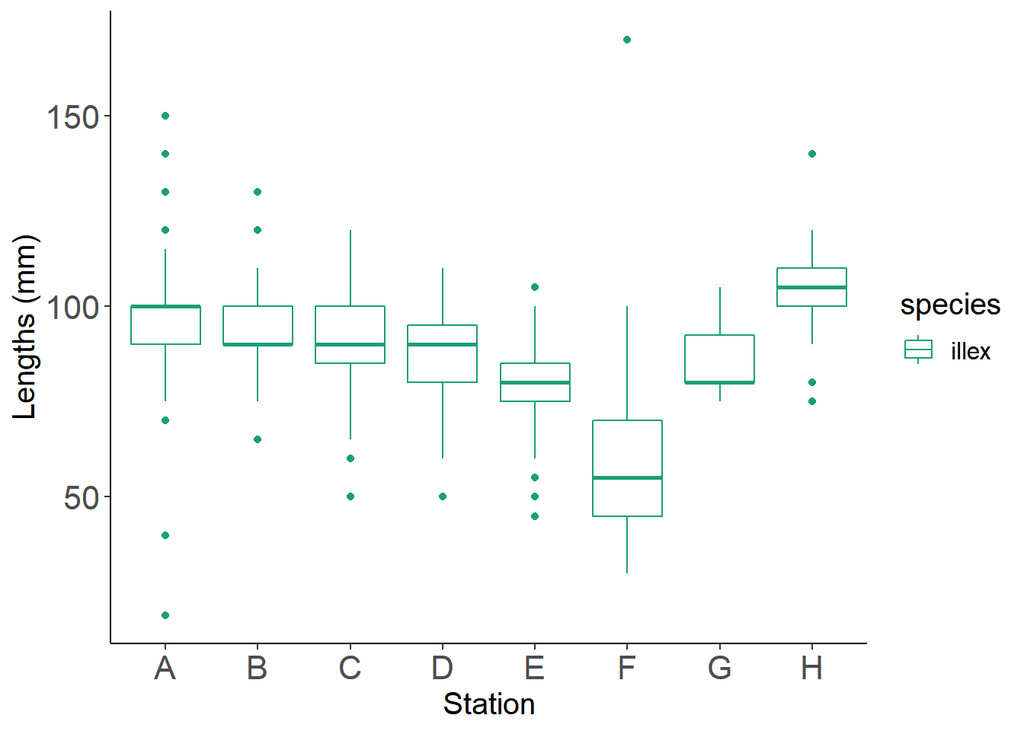

```r
# Just Illex
p = ggplot(lengths %>% filter(species == 'illex'),
           aes(x = factor(station), y = length, col = species))+
  labs(x = 'Station', y = 'Lengths (mm)') +
  scale_color_brewer(palette = "Dark2") +
  theme_classic() +
  #facet_wrap(~factor(fleet))
  geom_boxplot()

p = p +  theme(text = element_text(size = 15),
               axis.text=element_text(size = 16))
p
```

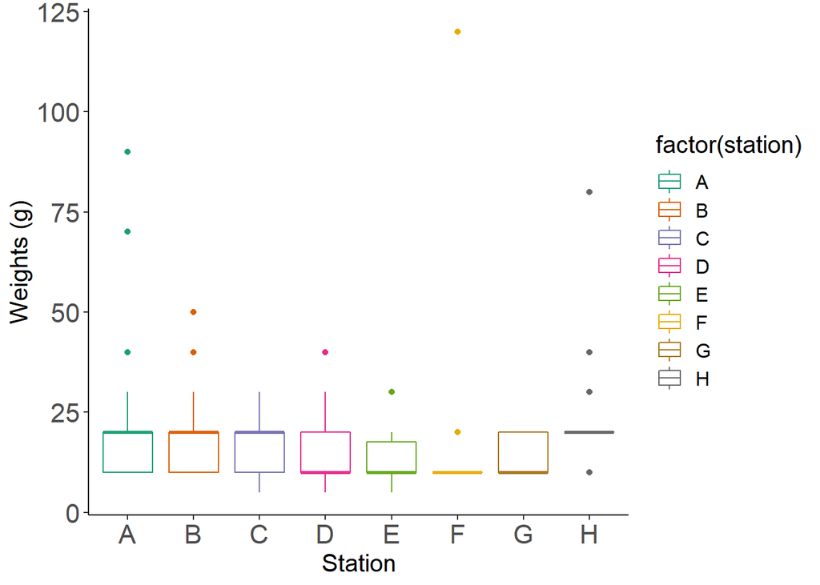

```r
# Just Illex
p = ggplot(wtml ,
           aes(x = factor(station), y = weight*1000, col = factor(station)))+
  labs(x = 'Station', y = 'Weights (g)') +
  scale_color_brewer(palette = "Dark2") +
  theme_classic() +
  #facet_wrap(~factor(fleet))
  geom_boxplot()

p = p +  theme(text = element_text(size = 15),
               axis.text=element_text(size = 16))
p
```

## Illex catch length/weight distributions

### Lengths

Ridge plot for quick glance of lengths across stations

```r
ggplot(lengths %>% filter(species == 'illex'),
       aes(x = length, y = factor(station), fill =  factor(station))) +
  geom_density_ridges(alpha = .8, color = 'white',
                      scale = 2.5, rel_min_height = .01) +
  labs(title = '2022 Illex Lengths', x = 'Length (mm)', y = 'Station', fill = 'Station') +
  guides(color = guide_legend(title = 'Station')) +
  theme_ridges() +
  theme_classic()
```

[output not shown]

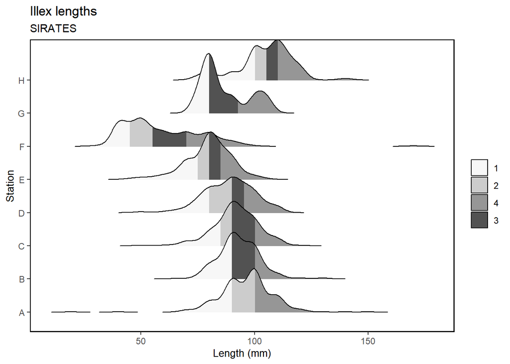

```r
ggplot(lengths %>% filter(species == 'illex'),
       aes(x = length, y = factor(station),
                          fill = stat(quantile))) +
  stat_density_ridges(quantile_lines = FALSE,
                      calc_ecdf = TRUE, rel_min_height = 0.0001,
                      geom = "density_ridges_gradient") +
  labs(title = 'Illex lengths',
       subtitle = 'SIRATES',
       x = 'Length (mm)', y = 'Station') +
  scale_fill_brewer(name = '', palette = 'Greys') +
  ecodata::theme_ts()
```

### Weights

Ridge plot for quick glance of weights across stations

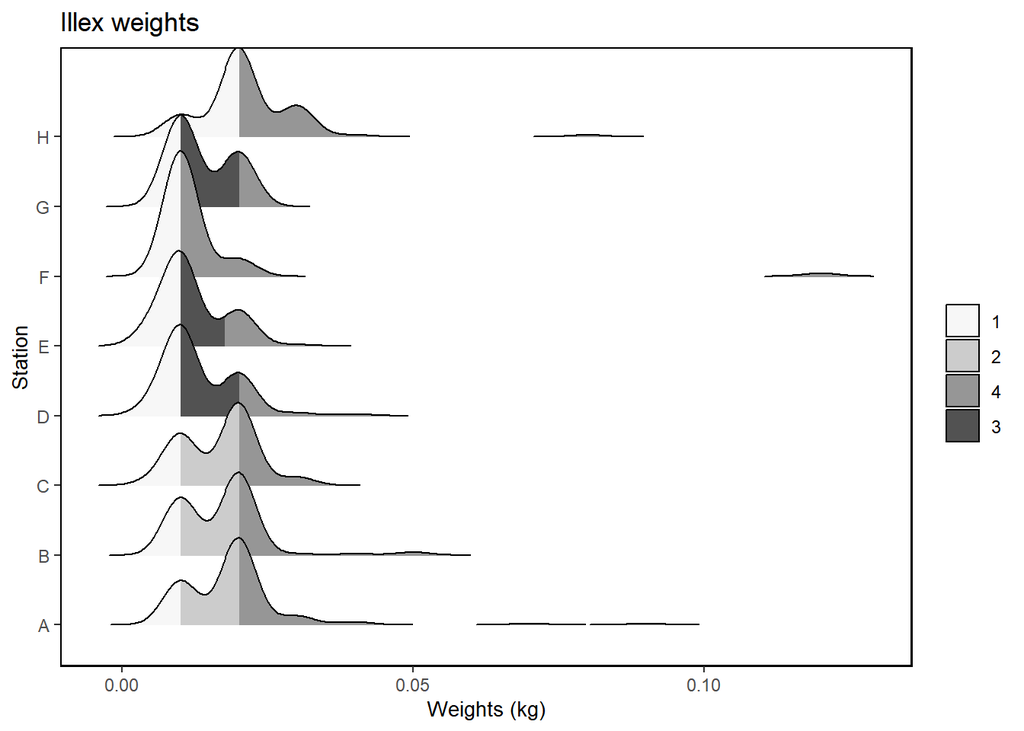

```r
ggplot(wtml,
       aes(x = weight, y = factor(station),
                          fill = stat(quantile))) +
  stat_density_ridges(quantile_lines = FALSE,
                      calc_ecdf = TRUE, rel_min_height = 0.0001,
                      geom = "density_ridges_gradient") +
  labs(title = 'Illex weights',
        x = 'Weights (kg)', y = 'Station') +
  scale_fill_brewer(name = '', palette = 'Greys') +
  ecodata::theme_ts()
```

Histograms of lengths across locations

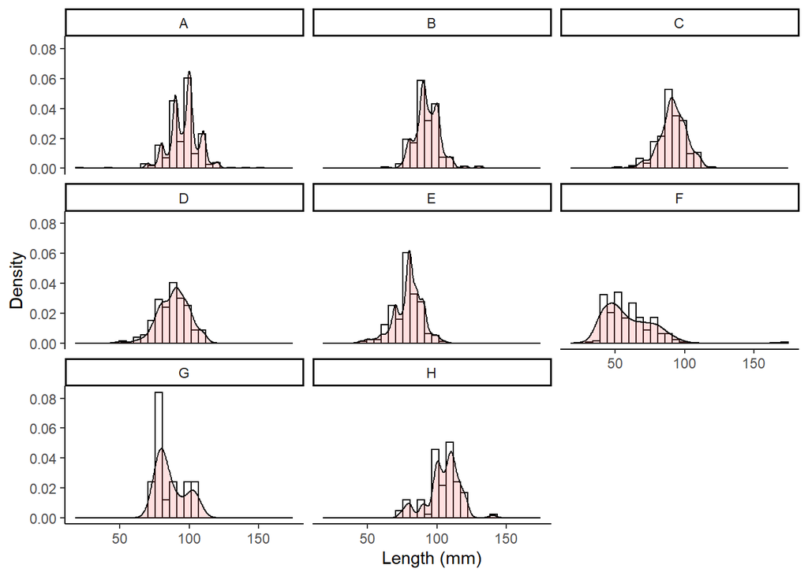

```r
# Just Illex
ggplot(lengths %>% filter(species == 'illex'),
       aes(x = length)) +
  geom_histogram(aes(y = ..density..),
                 colour = "black",
                 fill = "white") +
  geom_density(alpha = 0.2, fill = "#FF6666") +
  #labs(title = '2021') +
  xlab('Length (mm)') +
  ylab('Density') +
  theme_classic() +
  facet_wrap(~factor(station))
```

Histogram of weights across locations

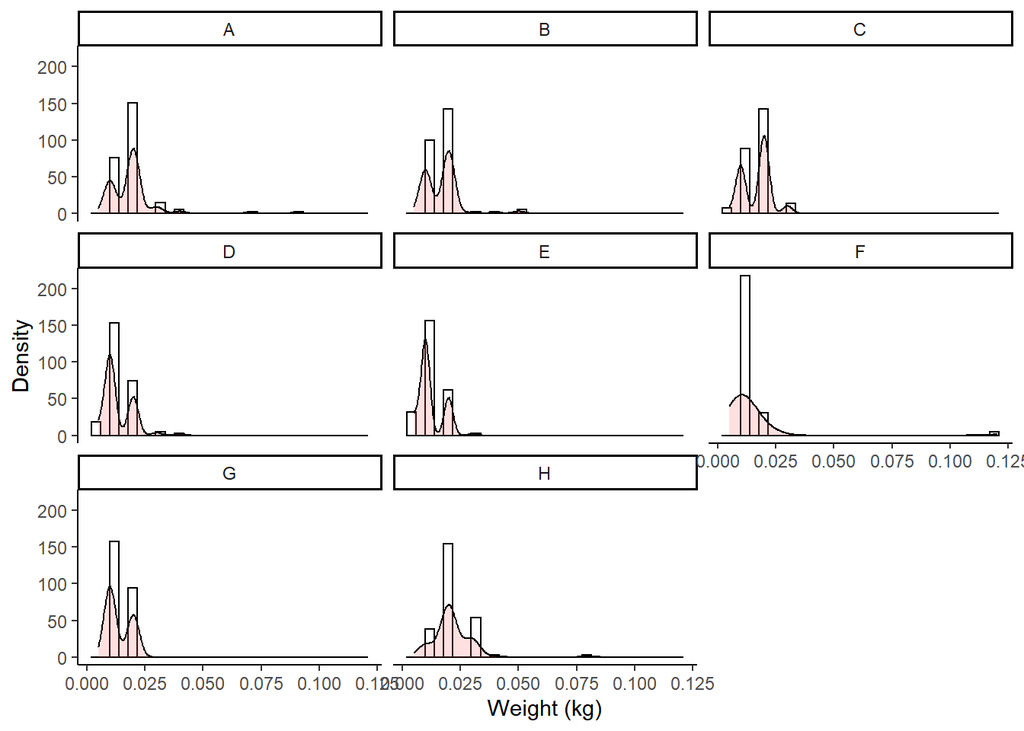

```r
# Just Illex
ggplot(wtml,
       aes(x = weight)) +
  geom_histogram(aes(y = ..density..),
                 colour = "black",
                 fill = "white") +
  geom_density(alpha = 0.2, fill = "#FF6666") +
  xlab('Weight (kg)') +
  ylab('Density') +
  theme_classic() +
  facet_wrap(~factor(station))
```

## Inspecting trends

Across all locations

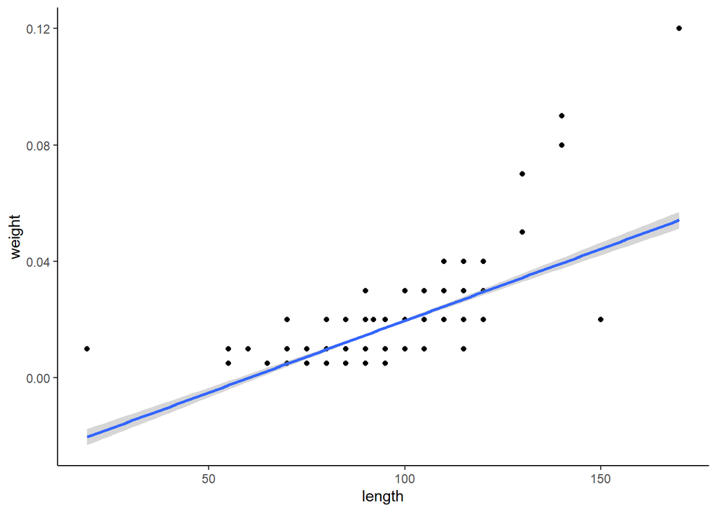

```r
#Plot series with trend

g <- ggplot(wtml, aes(length, weight)) +
  geom_point() +
  theme_classic()

g + stat_smooth(method = "lm",
              formula = y ~ x,
              geom = "smooth")
```

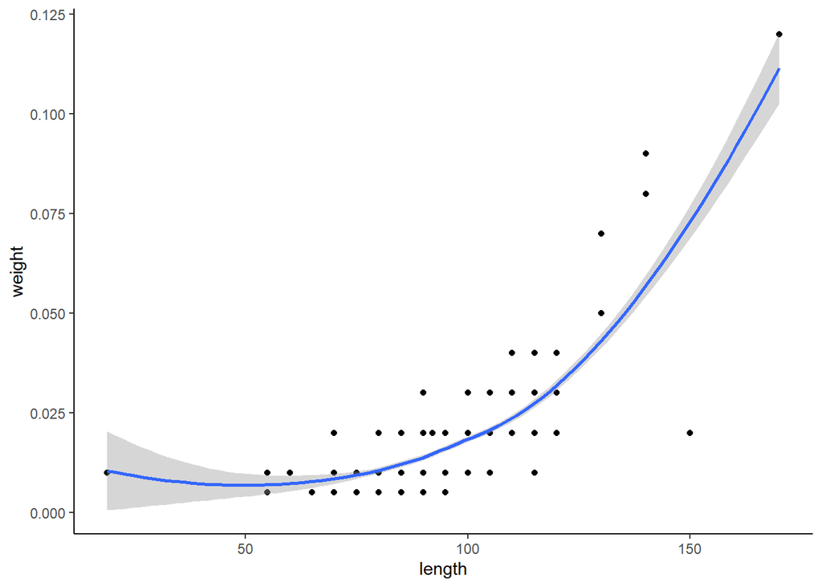

```r
g + stat_smooth(method = "loess",
              formula = y ~ x,
              geom = "smooth")
```

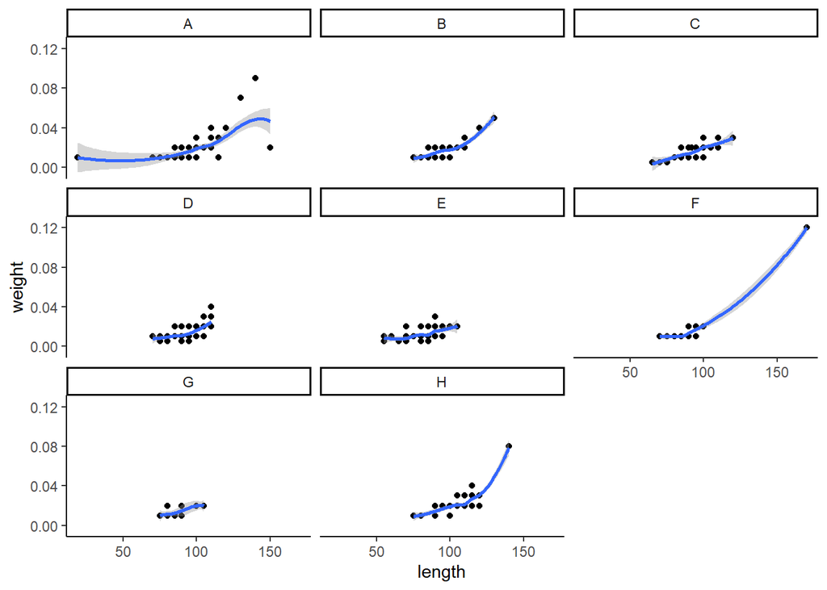

```r
g <- ggplot(wtml, aes(length, weight)) +
  geom_point() +
  theme_classic() +
  facet_wrap(~factor(station))

g+ stat_smooth(method = "loess",
              formula = y ~ x,
              geom = "smooth")
```

Relative condition (Kn) = W/W`where W` is the predicted length-specific mean weight for the fish population in a given region

```r
# Condition
wtml <- wtml %>% mutate(weight = weight * 1000)
wtml$W <- 0.04810*(wtml$length*.10)^2.71990
wtml$Kn <- wtml$weight/wtml$W
wtml$W21 <- 0.082888*(wtml$length*.10)^2.530143
wtml$Kn21 <- wtml$weight/wtml$W21
```

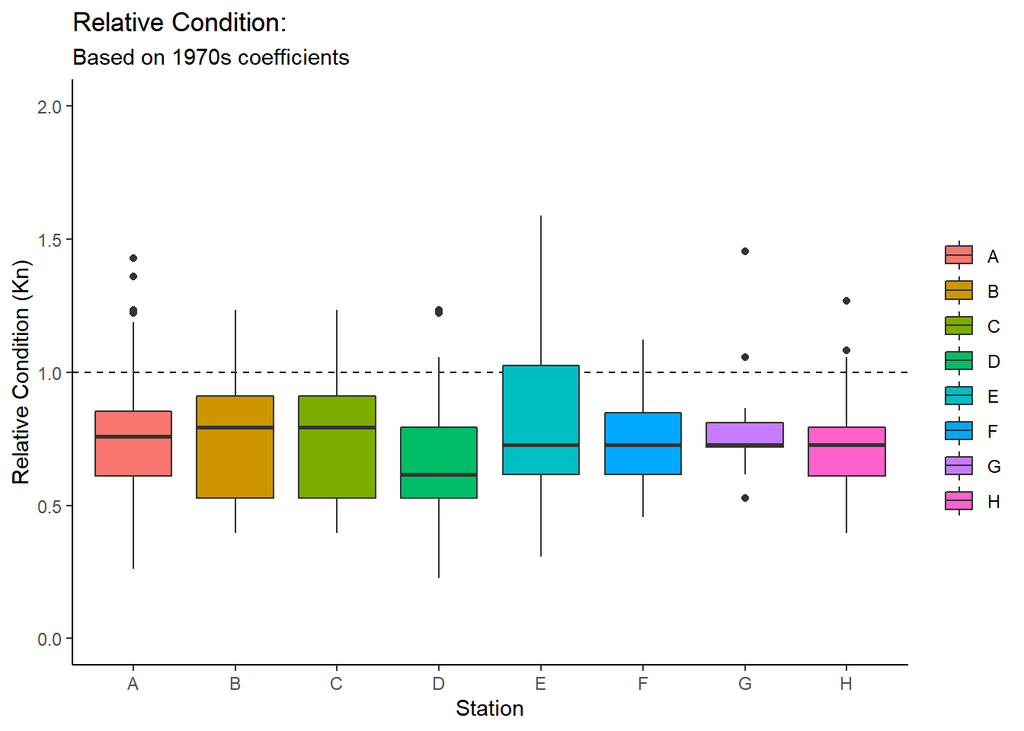

```r
ggplot(wtml, aes(x = factor(station), y = Kn, fill = factor(station))) +
  labs(x = 'Station', y = 'Relative Condition (Kn)',
       title = 'Relative Condition:',
       subtitle = 'Based on 1970s coefficients') +
  theme_classic() +
  guides(fill=guide_legend(title=NULL))+
  geom_hline(yintercept = 1, lty = 2) +
  ylim(0,2) +
  geom_boxplot()
```

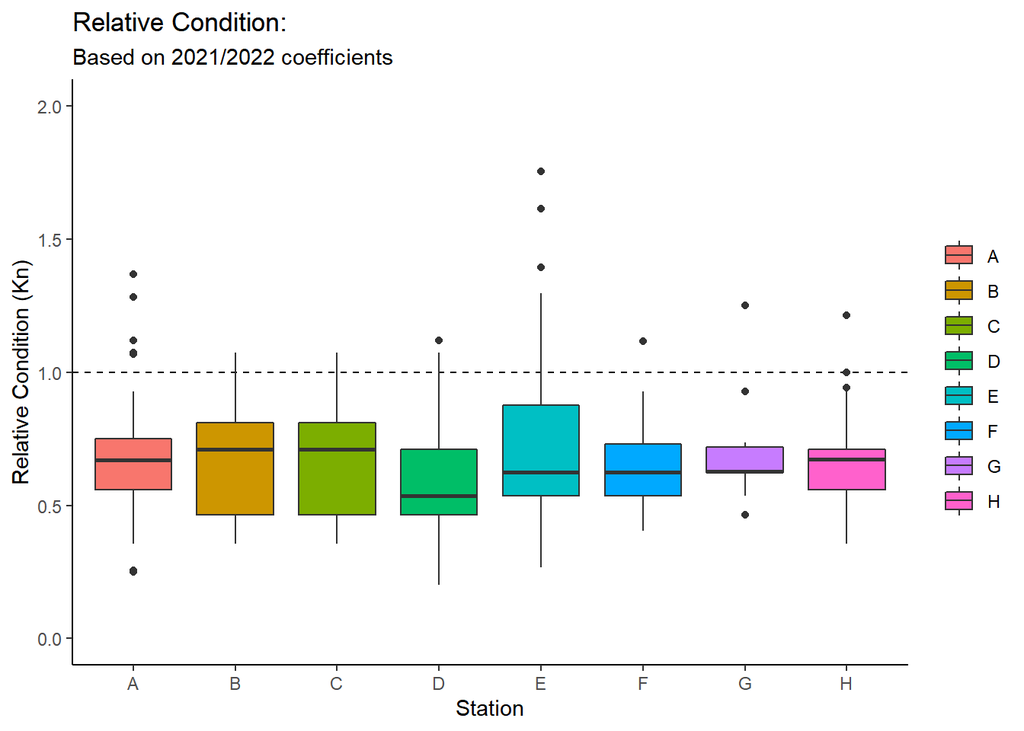

```r
ggplot(wtml,
            aes(x = factor(station), y = Kn21, fill = factor(station))) +
  labs(x = 'Station', y = 'Relative Condition (Kn)',
       title = 'Relative Condition:',
       subtitle = 'Based on 2021/2022 coefficients') +
  theme_classic() +
  guides(fill=guide_legend(title=NULL))+
  geom_hline(yintercept = 1, lty = 2) +
  ylim(0,2) +
  geom_boxplot()
```

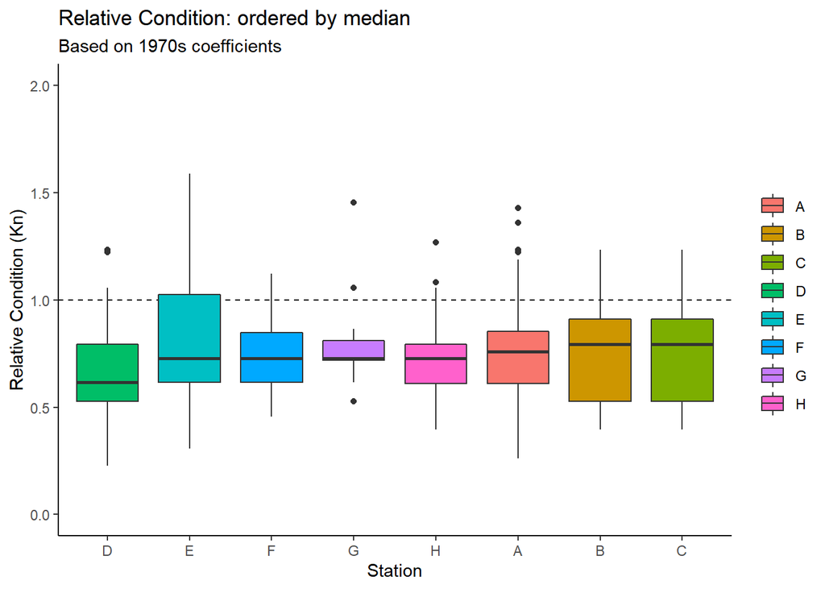

```r
# Ordered by median
ggplot(wtml,
            aes(x = reorder(station, Kn, median), y = Kn, fill = factor(station))) +
  labs(x = 'Station', y = 'Relative Condition (Kn)',
       title = 'Relative Condition: ordered by median',
       subtitle = 'Based on 1970s coefficients') +
  theme_classic() +
  guides(fill=guide_legend(title=NULL))+
  geom_hline(yintercept = 1, lty = 2) +
  ylim(0,2) +
  geom_boxplot()
```

A little data wrangling to map mean weight/condition by location

```r
# Add location based on net set lat lon
wtml$lat <- NA
wtml$lon <- NA

wtml <- wtml %>% relocate(lat, .before=length)
wtml <- wtml %>% relocate(lon, .before=length)
a <- subset(net_set, station == 'A',  select = c('lat', 'lon', 'station'))
b <- subset(net_set, station == 'B', select = c('lat', 'lon', 'station'))
c <- subset(net_set, station == 'C', select = c('lat', 'lon', 'station'))
d <- subset(net_set, station == 'D', select = c('lat', 'lon', 'station'))
e <- subset(net_set, station == 'E', select = c('lat', 'lon', 'station'))
f <- subset(net_set, station == 'F', select = c('lat', 'lon', 'station'))
g <- subset(net_set, station == 'G', select = c('lat', 'lon', 'station'))
h <- subset(net_set, station == 'H', select = c('lat', 'lon', 'station'))
locs1 <- which(wtml$station %in% a$station)
locs2 <- which(wtml$station %in% b$station)
locs3 <- which(wtml$station %in% c$station)
locs4 <- which(wtml$station %in% d$station)
locs5 <- which(wtml$station %in% e$station)
locs6 <- which(wtml$station %in% f$station)
locs7 <- which(wtml$station %in% g$station)
locs8 <- which(wtml$station %in% h$station)
wtml[locs1,2] <- a[1,1]
wtml[locs1,3] <- a[1,2]
wtml[locs2,2] <- b[1,1]
wtml[locs2,3] <- b[1,2]
wtml[locs3,2] <- c[1,1]
wtml[locs3,3] <- c[1,2]
wtml[locs4,2] <- d[1,1]
wtml[locs4,3] <- d[1,2]
wtml[locs5,2] <- e[1,1]
wtml[locs5,3] <- e[1,2]
wtml[locs6,2] <- f[1,1]
wtml[locs6,3] <- f[1,2]
wtml[locs7,2] <- g[1,1]
wtml[locs7,3] <- g[1,2]
wtml[locs8,2] <- h[1,1]
wtml[locs8,3] <- h[1,2]
```

```r
wtml_stats2 <- wtml %>%
  group_by(station) %>%
  summarise(n = n(),
         wt_mean = mean(weight),
            ml_mean = mean(length),
            wt_median = median(weight),
            ml_median = median(length),
            wt_sd = sd(weight),
            ml_sd = sd(length),
            wt_max = max(weight),
            ml_max = max(length),
            wt_min = min(weight),
            ml_min = min(length),
            kn_mean = mean(Kn),
            kn_median = median(Kn),
            lat = mean(lat),
            lon = mean(lon))
```

Plotting condtion and mean weight in space

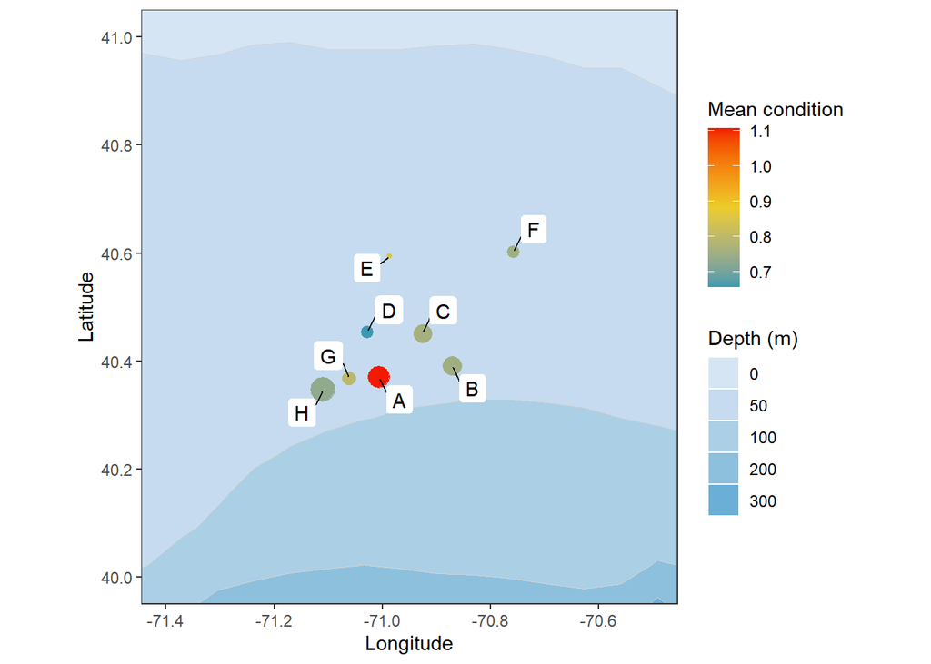

```r
wespal2 <- wes_palette("Zissou1", 3, type = "continuous")


p3 = ggplot() +
  geom_contour_filled(data = atl,
                      aes(x=x,y=y,z=-1*z, color = 1*z),
                      breaks=c(0,50,100,250,500,Inf),
                      size=c(0.3)) +
  scale_fill_manual(values = blues2, # 5:20
                    name = paste("Depth (m)"),
                    labels = depths) +
  geom_contour(data = atl,
               aes(x=x,y=y,z=-1*z),
               breaks=c(0,50,100,250,500,Inf),
               size=c(0.3),
               col = 'lightgrey') +
  new_scale_fill() +
  geom_point(data = wtml_stats2,
            aes(x = lon, y = lat, color = kn_mean, size = wt_mean),
          show.legend = 'point') +
  scale_color_gradientn(colours = wespal2,
                        name = ('Mean condition')) +
  ggrepel::geom_label_repel(data = net_set_sf,
                            aes(label = station, geometry = geometry),
                            stat = "sf_coordinates",
                            min.segment.length = 0,
                            label.size = NA) +
  geom_polygon(data = coast, aes(x=lon, y = lat, group = group),
               color = 'gray20', fill = "wheat3") +
  coord_sf(xlim = c(-71.4,-70.5), ylim = c(40.0,41.0),
           datum = sf::st_crs(4326)) +
  xlab('Longitude') +
  ylab('Latitude')+
  guides(fill = 'none') + #color = FALSE,
  theme_bw()

p3 + geom_text()
```

## Estimating age at weight

Code below computes age estimate for each weight Parameters of weight at age estimation per Hendrickson and Hart 2006 for males and females combined. The formula for Weight as a function of Age is: weight = alpha * age^beta, therefore age estimate is the inverse: (weight/alpha)^(1/beta)

## Frequency tables

Generate weight/length frequencies

```r
tabw = table(wtml$weight)
wtml %>% group_by(weight) %>% tally()
```

```
## # A tibble: 10 x 2
##    weight     n
##     <dbl> <int>
##  1      5    23
##  2     10   294
##  3     20   290
##  4     30    33
##  5     40     5
##  6     50     2
##  7     70     1
##  8     80     1
##  9     90     1
## 10    120     1
```

```r
#count(wtml, 'length')
tabl = table(wtml$length)
wtml %>% group_by(length) %>% tally()
```

```
## # A tibble: 20 x 2
##    length     n
##     <int> <int>
##  1     19     1
##  2     55     2
##  3     60     3
##  4     65     2
##  5     70    23
##  6     75    21
##  7     80    98
##  8     85    60
##  9     90   126
## 10     92     1
## 11     95    78
## 12    100   113
## 13    105    39
## 14    110    54
## 15    115    13
## 16    120    10
## 17    130     3
## 18    140     2
## 19    150     1
## 20    170     1
```

```r
# CrossTable in R
CrossTable(wtml$weight, wtml$length, prop.t=TRUE, prop.r=TRUE, prop.c=TRUE)
```

[output not shown]

Age of 70 days is approximately 10 weeks old, the xaxis then increases by 2 weeks Birth weeks of 18:22 correspond to May 2:May 30, 2022 23-25 June 6, June 20th

```r
library(patchwork)
```

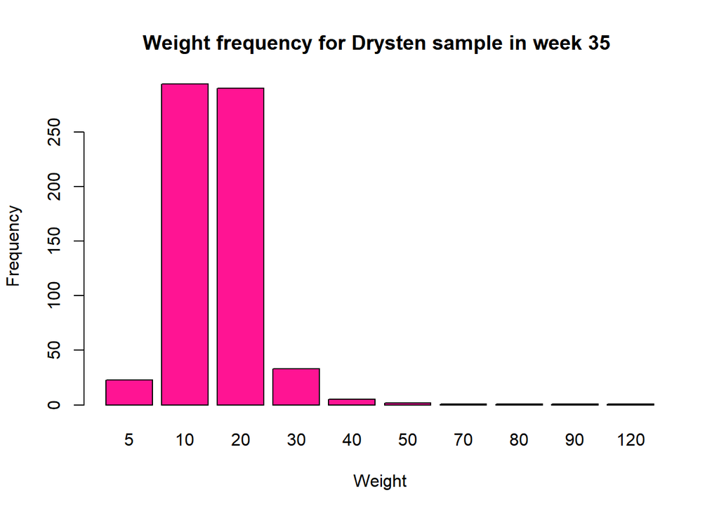

```r
# estimate age in days
alpha<-1.12e-6
beta<-3.60
wtml$age.est<-(wtml$weight/alpha)^(1/beta)
tab.w = table(wtml$weight)
barplot(tab.w, main=paste("Weight frequency for Drysten sample in week 35 "),
        xlab = "Weight", ylab = "Frequency", col='deeppink')
```

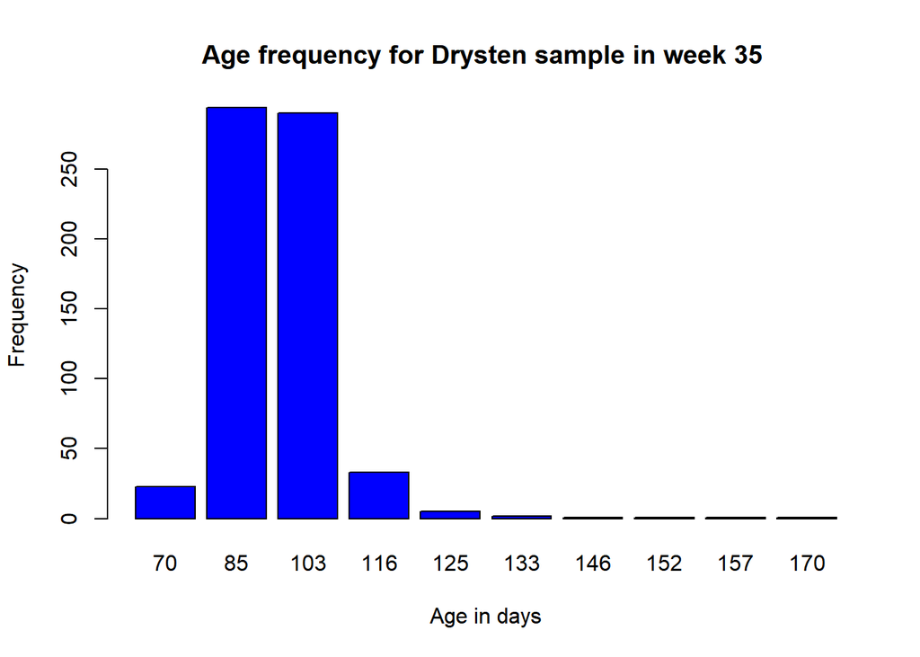

```r
tab.age = table(round(wtml$age.est))
barplot(tab.age, main=paste("Age frequency for Drysten sample in week 35 "),
        xlab = "Age in days", ylab = "Frequency", col='blue')
```

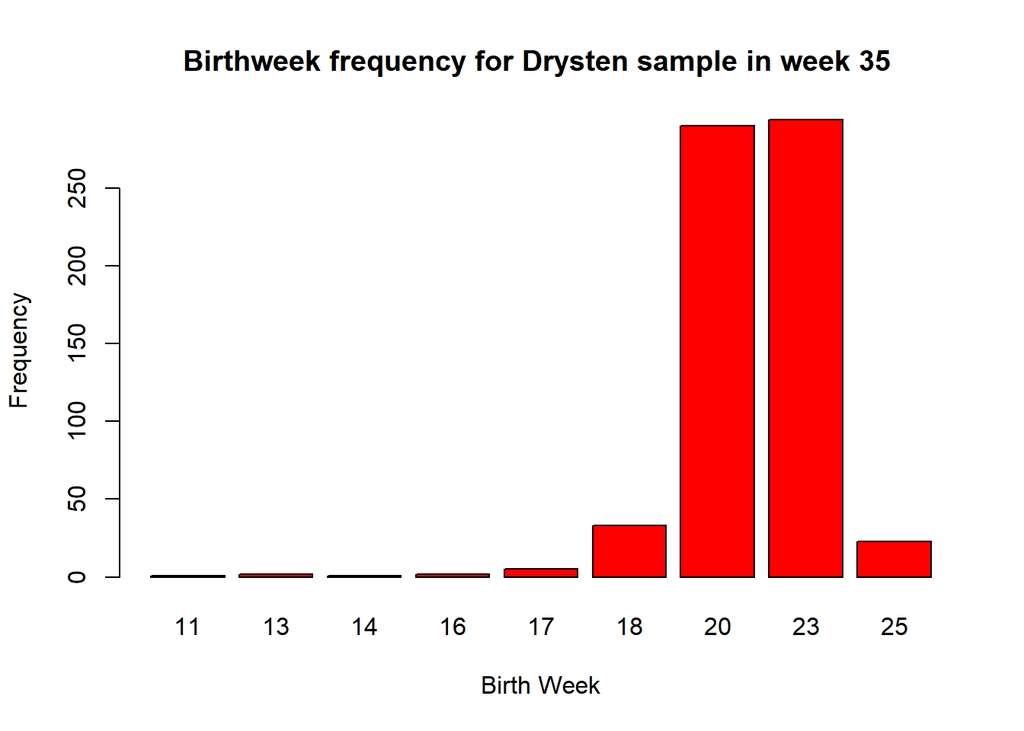

```r
# Analysis of putative  Birth weeks
# Compute birth week as function of age at capture
wtml$week <- 35
wtml$birth.week<-round(wtml$week-wtml$age.est/7)
b.week.table<-table(round(wtml$birth.week))
barplot(b.week.table, main=paste("Birthweek frequency for Drysten sample in week 35 "),
             xlab="Birth Week", ylab="Frequency", col="red")
```

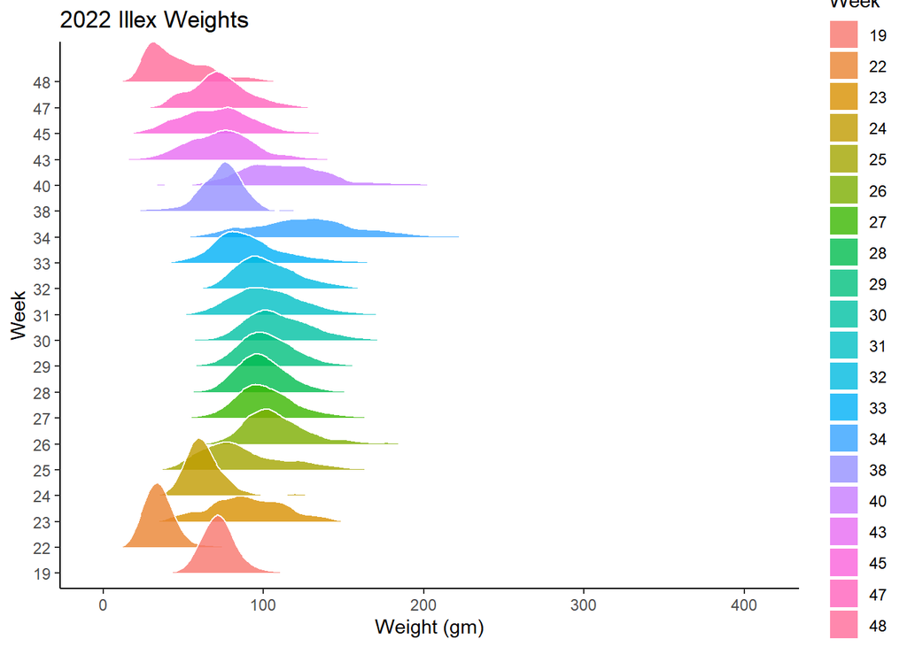

```r
ml_wt_22 <- read.csv('ml_wt_21_22.csv')
wt_22 <- ml_wt_22 %>%
  filter(PARAM_TYPE == 'WT') %>%
  rename(weight = PARAM_VALUE_NUM)



w1 = ggplot(wt_22 %>% filter(year == 2022),
       aes(x = weight, y = factor(week), fill =  factor(week))) +
  geom_density_ridges(alpha = .8, color = 'white',
                      scale = 2.5, rel_min_height = .01) +
  labs(title = '2022 Illex Weights', x = 'Weight (gm)', y = 'Week', fill = 'Week') +
  guides(color = guide_legend(title = 'Week')) +
  theme_ridges() +
  theme_classic()
w1
```